# Computer Lab 2 Covid

# Import additional country indicators

The following three files will add the following variables to your dataframe

- Land_Area_sqkm
- HealthExp
- GDPpc
- Obese_Pcent
- Over_65s
- Diabetis

Make sure that these files are saved in your working directory.

Check whether `data` indeed contains these variables. Which of the following commands is useful for this?

```r
view(data)
str(data)
```

```
## 'data.frame':    7646 obs. of  17 variables:
##  $ countryCode   : Factor w/ 214 levels "","ABW","AFG",..: 3 3 3 3 3 3 3 3 3 3 ...
##  $ country       : Factor w/ 219 levels "Afghanistan",..: 1 1 1 1 1 1 1 1 1 1 ...
##  $ dates         : Date, format: "2020-01-20" "2020-05-25" ...
##  $ year_week     : Factor w/ 59 levels "2020-01","2020-02",..: 4 22 26 39 43 57 49 52 37 35 ...
##  $ cases_weekly  : int  0 4623 2134 183 633 267 1672 1994 318 163 ...
##  $ deaths_weekly : int  0 39 140 12 22 16 137 88 8 15 ...
##  $ geoId         : Factor w/ 213 levels "AD","AE","AF",..: 3 3 3 3 3 3 3 3 3 3 ...
##  $ popData2019   : num  38928341 38928341 38928341 38928341 38928341 ...
##  $ continentExp  : Factor w/ 5 levels "Africa","America",..: 3 3 3 3 3 3 3 3 3 3 ...
##  $ pc_cases      : num  0 11.88 5.48 0.47 1.63 ...
##  $ pc_deaths     : num  0 0.1002 0.3596 0.0308 0.0565 ...
##  $ Land_Area_sqkm: num  653000 653000 653000 653000 653000 653000 653000 653000 653000 653000 ...
##  $ HealthExp     : num  9.4 9.4 9.4 9.4 9.4 ...
##  $ GDPpc         : num  530 530 530 530 530 ...
##  $ Obese_Pcent   : num  5.5 5.5 5.5 5.5 5.5 5.5 5.5 5.5 5.5 5.5 ...
##  $ Over_65s      : num  2.62 2.62 2.62 2.62 2.62 ...
##  $ Diabetis      : num  9.2 9.2 9.2 9.2 9.2 9.2 9.2 9.2 9.2 9.2 ...
```

```r
summary(data)
```

```
##   countryCode          country         dates              year_week
##  AFG    :  59   Afghanistan:  59   Min.   :2019-12-30   2020-46: 147
##  ARM    :  59   Algeria    :  59   1st Qu.:2020-05-11   2020-47: 147
##  AUS    :  59   Armenia    :  59   Median :2020-08-10   2020-48: 147
##  AUT    :  59   Australia  :  59   Mean   :2020-08-10   2020-49: 147
##  AZE    :  59   Austria    :  59   3rd Qu.:2020-11-09   2020-50: 147
##  BEL    :  59   Azerbaijan :  59   Max.   :2021-02-08   2020-51: 147
##  (Other):7292   (Other)    :7292                        (Other):6764
##   cases_weekly      deaths_weekly        geoId       popData2019
##  Min.   :-17182.0   Min.   :-875.0   AF     :  59   Min.   :7.199e+04
##  1st Qu.:    32.0   1st Qu.:   0.0   AM     :  59   1st Qu.:3.278e+06
##  Median :   425.5   Median :   6.0   AT     :  59   Median :1.033e+07
##  Mean   :  9486.6   Mean   : 222.5   AU     :  59   Mean   :5.086e+07
##  3rd Qu.:  4007.2   3rd Qu.:  69.0   AZ     :  59   3rd Qu.:3.347e+07
##  Max.   :641814.0   Max.   :9025.0   BE     :  59   Max.   :1.439e+09
##                                      (Other):7292
##   continentExp     pc_cases          pc_deaths       Land_Area_sqkm
##  Africa :2042   Min.   :-181.833   Min.   :-6.7288   Min.   :     300
##  America:1307   1st Qu.:   0.472   1st Qu.: 0.0000   1st Qu.:   39500
##  Asia   :1909   Median :   4.293   Median : 0.0604   Median :  192000
##  Europe :2267   Mean   :  41.957   Mean   : 0.7671   Mean   :  801555
##  Oceania: 121   3rd Qu.:  36.555   3rd Qu.: 0.5748   3rd Qu.:  579000
##                 Max.   :1033.120   Max.   :45.5183   Max.   :16400000
##                                                      NA's   :241
##    HealthExp          GDPpc           Obese_Pcent       Over_65s
##  Min.   : 2.246   Min.   :   310.3   Min.   : 2.10   Min.   : 1.523
##  1st Qu.: 4.580   1st Qu.:  2537.5   1st Qu.: 8.90   1st Qu.: 3.627
##  Median : 6.526   Median :  6716.9   Median :20.50   Median : 7.015
##  Mean   : 6.500   Mean   : 16580.2   Mean   :18.39   Mean   : 9.552
##  3rd Qu.: 8.353   3rd Qu.: 19441.1   3rd Qu.:24.60   3rd Qu.:15.201
##  Max.   :11.876   Max.   :117806.2   Max.   :37.90   Max.   :28.002
##  NA's   :429      NA's   :429                        NA's   :145
##     Diabetis
##  Min.   : 1.000
##  1st Qu.: 5.100
##  Median : 6.500
##  Mean   : 7.594
##  3rd Qu.: 9.600
##  Max.   :22.100
##
```

```r
names(data)
```

```
##  [1] "countryCode"    "country"        "dates"          "year_week"
##  [5] "cases_weekly"   "deaths_weekly"  "geoId"          "popData2019"
##  [9] "continentExp"   "pc_cases"       "pc_deaths"      "Land_Area_sqkm"
## [13] "HealthExp"      "GDPpc"          "Obese_Pcent"    "Over_65s"
## [17] "Diabetis"
```

Now we need to calculate the Population density.

```r
data <- data %>% XXXX(popdens = XXXX/XXXX)  # calculate population density
```

Confirm that the average population density in your dataset is 235.073.

```
##     Min.  1st Qu.   Median     Mean  3rd Qu.     Max.     NA's
##    2.115   31.496   83.090  235.073  162.079 8251.542      241
```

# Average data over the sample period

What we now do is to aggregate the weekly cases and deaths data. In the Lecture and the Review and Q&A session we did this over the entire available sample period. Could there be reasons why we may not want to do this over the entire period?

This was the code we used in the Week2 material to calculate these averages (including all available data).

```r
table3 <- data %>% group_by(country) %>% # groups by Country
            summarise(Avg_cases = mean(pc_cases,na.rm = TRUE),
                      Avg_deaths = mean(pc_deaths,na.rm = TRUE),
                      PopDen = mean(popdens))
```

Find a way to adjust this bit of code such that the average calculations are only based on data from “2020-06-01” onwards. What operation should you use in place of `XXXX`? Here is a link tohttps://s3.amazonaws.com/assets.datacamp.com/blog_assets/Tidyverse+Cheat+Sheet.pdf. There are 4 major type of operations you can perform in a pipe (`%>%`), `filter`, `arrange`, `mutate`, `summarise\summarize` and (although not on the cheat sheet) `select`. Which one is the one to use?

Also note the following. The summarise function is designed to summarise information, e.g. for a particular country, which varies in the country specific sample. However, we not only want to summarise the number of weekly cases and deaths, we also want to have the country information for population density, obesity, diabetis, Over 65s, GDPpc, HealthExp and the countries continent. Below you see, inside the summarise function terms like `PopDen = first(popdens)`. This selects the first `popdens` observation for a particular country. As all these variables do not vary through our sample this little trick delivers exactly what we want.

```r
table3 <- data %>% XXXX %>%
            group_by(country) %>% # groups by Country
            summarise(Avg_cases = mean(pc_cases,na.rm = TRUE),
                      Avg_deaths = mean(pc_deaths,na.rm = TRUE),
                      PopDen = first(popdens),
                      Obese = first(Obese_Pcent),
                      Diabetis = first(Diabetis),
                      Over_65s = first(Over_65s),
                      GDPpc = first(GDPpc)/1000,  # calculate GDPpc in $1000s
                      HealthExp = first(HealthExp),
                      Continent = first(continentExp))
```

After you selected, check `head(table3)` to confirm that you got the same result.

```
## # A tibble: 6 x 10
##   country Avg_cases Avg_deaths PopDen Obese Diabetis Over_65s  GDPpc HealthExp
##   <fct>       <dbl>      <dbl>  <dbl> <dbl>    <dbl>    <dbl>  <dbl>     <dbl>
## 1 Afghan~      2.80     0.151    59.6   5.5      9.2     2.62  0.530      9.40
## 2 Albania     87.3      1.45    104.   21.7      9      14.2   5.22       5.26
## 3 Algeria      6.24     0.141    18.4  27.4      6.7     6.55  4.11       6.22
## 4 Andorra    347.       1.99    162.   25.6      7.7    NA    42.1        6.71
## 5 Angola       1.67     0.0401   26.3   8.2      4.5     2.20  3.44       2.55
## 6 Argent~    120.       2.98     16.5  28.3      5.9    11.2  11.7        9.62
## # ... with 1 more variable: Continent <fct>
```

Let’s create a few plots which show the average death numbers against some of our country specific information.

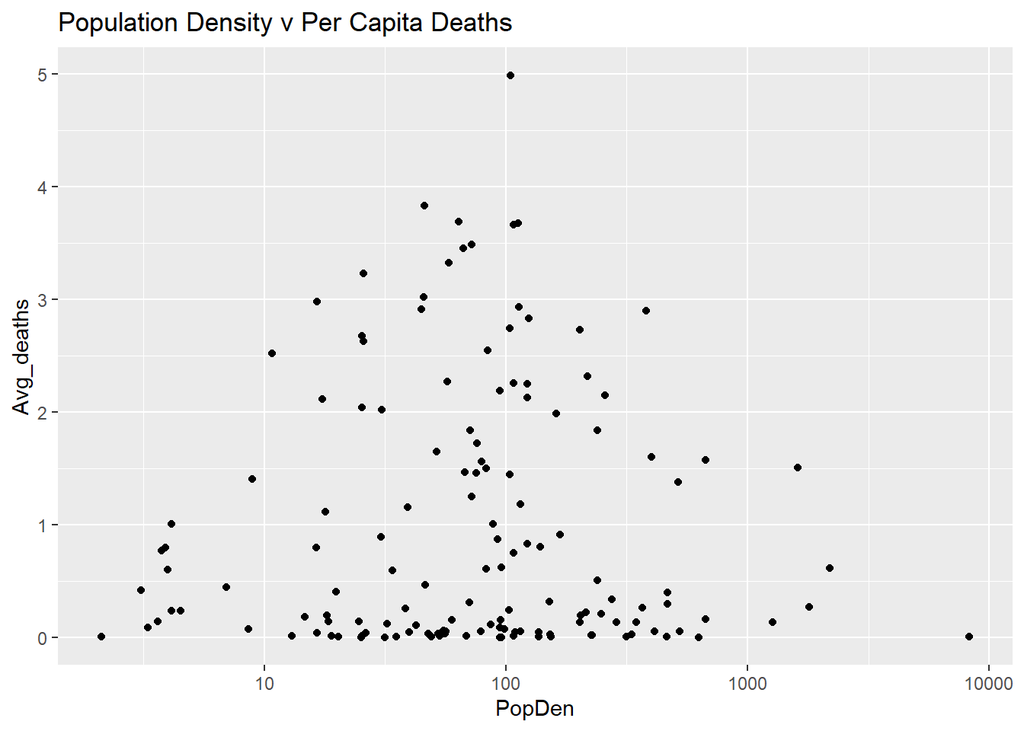

```r
ggplot(table3,aes(PopDen,Avg_deaths)) +
  geom_point() +
  scale_x_log10() +
  ggtitle("Population Density v Per Capita Deaths")
```

Now replicate the following graphs.

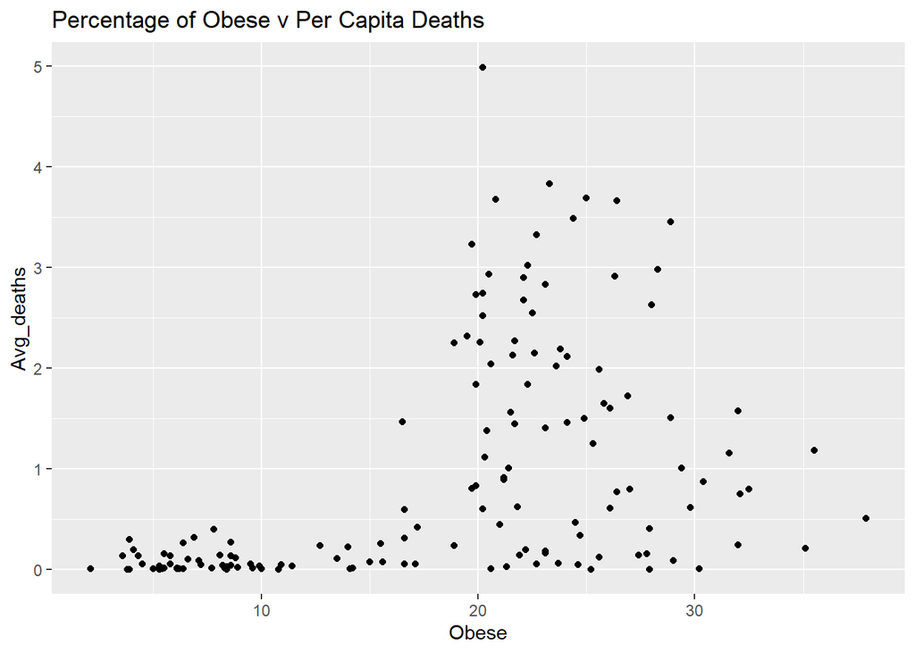

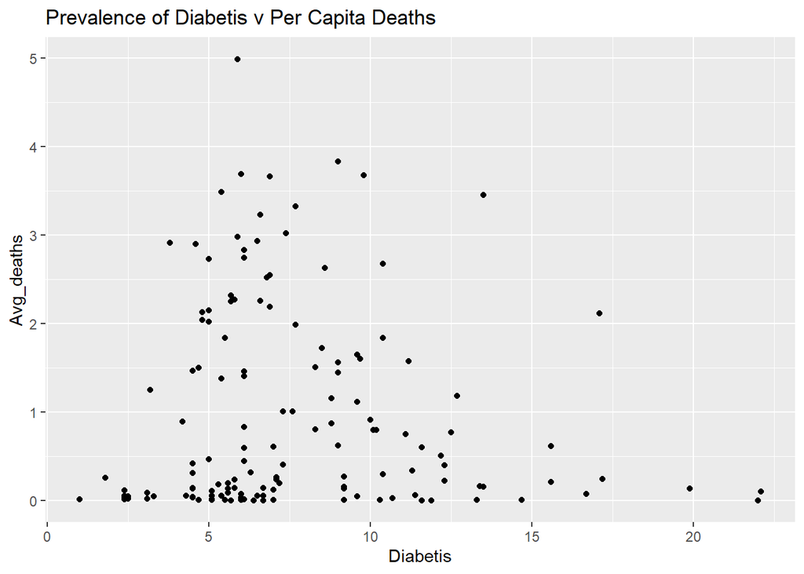

Let’s also create plots of deaths against the proportion of over 65s, but this time we want to split the graph according to continents.

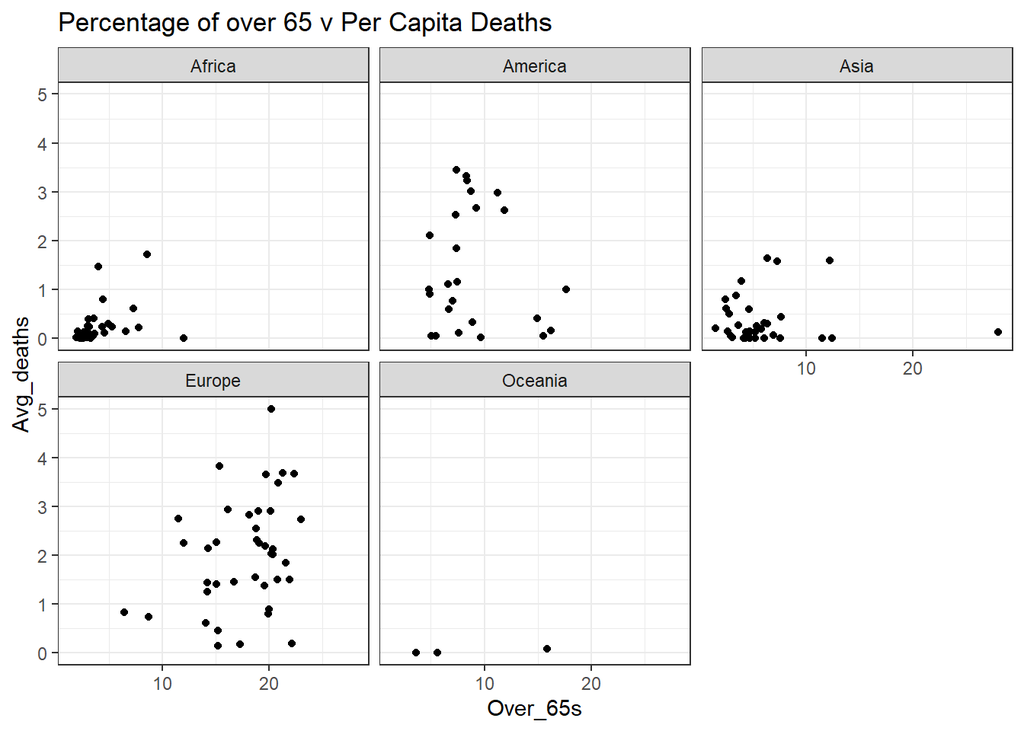

Nice, right?! Check out the https://rstudio.com/wp-content/uploads/2015/03/ggplot2-cheatsheet.pdf for more tricks and illustrtaions of this packages’ capabilities.

# Testing for equality of means

Let’s perform some hypothesis tests to check whether there are significant differences between the average rates of cases and deaths since June 2020 between continents.

We therefore continue to work with the data in `table3`. In `table4` we calculate continental averages.

```r
table4 <- table3 %>%
              group_by(Continent) %>%
              summarise(CAvg_cases = mean(Avg_cases, na.rm = TRUE),
                        CAvg_deaths = mean(Avg_deaths, na.rm = TRUE),
                        n = n()) %>% print()
```

```
## # A tibble: 5 x 4
##   Continent CAvg_cases CAvg_deaths     n
##   <fct>          <dbl>       <dbl> <int>
## 1 Africa        10.2        0.198     42
## 2 America       52.2        1.37      26
## 3 Asia          35.6        0.349     35
## 4 Europe       126.         2.02      41
## 5 Oceania        0.813      0.0305     3
```

Let’s see whether we find the continental averages to be statistically significantly different. Say we compare the `avg_deaths` in America and Asia. So test the null hypothesis that $H_0: \mu_{AS}=\mu_{AM}$ (or $H_0: \mu_{AS}-\mu_{AM}=0$) against the alternative hypothesis that $H_A: \mu_{AS}\neq\mu_{AM}$, where $\mu$ represents the average death rate of countries in the respective continent over the sample period (here June onwards).

```r
test_data_AS <- table3 %>%
  filter(Continent == "Asia")      # pick Asian data


test_data_AM <- table3 %>%
  filter(Continent == "America")      # pick European data

t.test(test_data_AS$Avg_deaths,test_data_AM$Avg_deaths, mu=0)  # testing that mu = 0
```

```
##
##  Welch Two Sample t-test
##
## data:  test_data_AS$Avg_deaths and test_data_AM$Avg_deaths
## t = -3.9955, df = 30.75, p-value = 0.0003739
## alternative hypothesis: true difference in means is not equal to 0
## 95 percent confidence interval:
##  -1.5362818 -0.4976901
## sample estimates:
## mean of x mean of y
## 0.3491566 1.3661425
```

The difference in the averages is 0.3492 - 1.3661 = -1.0169 (about 1 in 100,000 population). We get a t-test ststiatic of almost -4. If in truth the two means were the same then we should expect the test statistic to be around 0. Is -4 far enough away from 0 for us to conclude that we should stop supporting the null hypothesis? The value of the t-test is almost -4. Is that big. If $H_0$ was correct (same average death rates in Ameraica and Asia) then we should on average expect the t-test to come out around a value of 0. So -4 is clearly not 0, but is it so far away from 0 that we should reject $H_0$?

The answer is yes and the p-value does tell us that it is. The p-value is 0.00037 or 0.037%. This means that if the $H_0$ was correct, the probability of getting a difference of -1 (per 100,000 population) or a more extreme difference is 0.037%. We judge this probability to be too small for us to coninue to support the $H_0$ and we reject the $H_0$. We do so as the p-value is smaller than any of the usual significance levels (10%, 5% or 1%).

We are not restricted to testing whether two population means are the same. You could also test whether the difference in the population is anything different but 0. Say a politician claims that evidently the case rate in Europe is larger by more than 50 per 100,000 population than the case rate in America.

Here our $H_0$ is $H_0: \mu_{EU}=\mu_{AM}+50$ (or $\mu_{EU}-\mu_{AM}=50$) and we would test this against an alternative hypothesis of $H_0: \mu_{EU}>\mu_{AM}+50$ (or $H_0: \mu_{EU}-\mu_{AM}>50$). Here the statement of the politician is represented in the $H_A$.

```r
test_data_EU <- table3 %>%
  filter(Continent == "Europe")      # pick Asian data

test_data_AM <- table3 %>%
  filter(Continent == "America")      # pick European data

t.test(test_data_EU$Avg_cases,test_data_AM$Avg_cases, mu=50, alternative = "greater")
```

```
##
##  Welch Two Sample t-test
##
## data:  test_data_EU$Avg_cases and test_data_AM$Avg_cases
## t = 1.6748, df = 64.057, p-value = 0.04942
## alternative hypothesis: true difference in means is greater than 50
## 95 percent confidence interval:
##  50.0819     Inf
## sample estimates:
## mean of x mean of y
## 125.64828  52.16356
```

Note the following. The parameter `mu` now takes the value 50 as we are hypothesising that the difference inthe means in 50 (or larger than that in the $H_A$). Also, in contrast to the pevious test we now care whether the deviation is less or greater than 50. In this case we wonder whether it is really greater. Hence we use the additional input into the test function, `alternative = "greater"`. (The default for this input is `alternative = "two.sided"` and that is what is used, as in the previous case, if you don’t add it to the `t.test` function). Also check `?t.test` for an explanation of these optional input parameters.

Again we find ourselves asking whether the sample difference we obtained (73.4847) is consistent with the null hypothesis (of the population difference being 50). Here the answer is subtle. The p-value is 0.04942, so the probability of optaining a sample difference as big as 73.4847 (or bgger) is just a little below 5%. Say we set out to perform a test at a 10% significance level, then we would judge a probability of just below 5% to be too small nd hence we would reject the null hypothesis. If however we set out to perform a test at a 1% significance level then we would not reject the null hypothesis.

So let’s perform another test. An European opposition politicial is lamenting that the European case rate is more than 100 (per 100,000 population) larger than that in Asia. Perform the appropriate hypothesis test.

```r
t.test(test_data_XXXX$Avg_cases,test_data_XXXX$Avg_cases, mu=XXXX, alternative = XXXX)
```

```
##
##  Welch Two Sample t-test
##
## data:  test_data_EU$Avg_cases and test_data_AS$Avg_cases
## t = -0.72819, df = 73.535, p-value = 0.7656
## alternative hypothesis: true difference in means is greater than 100
## 95 percent confidence interval:
##  67.12612      Inf
## sample estimates:
## mean of x mean of y
## 125.64828  35.64747
```

The p-value is certainly larger than any of the usual significance levels and we fail to reject $H_0$. This means that the opposition politician’s statement is not supported by the data.

# Regression and inference

To perform inference in the context of regressions it pays to use an additional package, the `car` package. So please load this package.

```r
library(car)
```

If you get an error message it is likely that you first have to install that package.

In the lecture we talked about a base case regression

$Avg\_deaths_i = \alpha + \beta_1 ~GDPpc_i + \beta_2~ HealthExp_i + u_i$

Let us estimate this again using the average rates calculated on data from June onwards only (hence the results here will be somewhat different to those in the lecture).

```r
mod3 <- lm(Avg_deaths~GDPpc+HealthExp,data=table3)
stargazer(mod3,type = "text")
```

```
##
## ===============================================
##                         Dependent variable:
##                     ---------------------------
##                             Avg_deaths
## -----------------------------------------------
## GDPpc                          0.004
##                               (0.005)
##
## HealthExp                    0.191***
##                               (0.042)
##
## Constant                      -0.291
##                               (0.265)
##
## -----------------------------------------------
## Observations                    138
## R2                             0.178
## Adjusted R2                    0.166
## Residual Std. Error      1.060 (df = 135)
## F Statistic           14.614*** (df = 2; 135)
## ===============================================
## Note:               *p<0.1; **p<0.05; ***p<0.01
```

We see that, for these data, the `HealthExp` variable remains statistically significant although the `GDPpc` variable is now not statistically significant.

```r
mod4 <- lm(Avg_deaths~GDPpc+XXXX,data=table3)
stargazer(mod3,mod4,type = "text")
```

```
##
## ===================================================================
##                                   Dependent variable:
##                     -----------------------------------------------
##                                       Avg_deaths
##                               (1)                     (2)
## -------------------------------------------------------------------
## GDPpc                        0.004                 -0.012***
##                             (0.005)                 (0.004)
##
## HealthExp                  0.191***                  0.053
##                             (0.042)                 (0.040)
##
## Obese                                              0.047***
##                                                     (0.011)
##
## Over_65s                                           0.089***
##                                                     (0.016)
##
## Diabetis                                            -0.028
##                                                     (0.023)
##
## Constant                    -0.291                 -0.647**
##                             (0.265)                 (0.291)
##
## -------------------------------------------------------------------
## Observations                  138                     135
## R2                           0.178                   0.443
## Adjusted R2                  0.166                   0.421
## Residual Std. Error    1.060 (df = 135)        0.886 (df = 129)
## F Statistic         14.614*** (df = 2; 135) 20.527*** (df = 5; 129)
## ===================================================================
## Note:                                   *p<0.1; **p<0.05; ***p<0.01
```

If you want to perform a hypothesis test say on $\beta_3$ (the coefficient on the `Obese` variable), then the usual hypothesis to pose is $H_0: \beta_3 = 0$ versus $H_A: \beta_3 \neq 0$. It is the p-value to that hypothesis test which is represented by the asteriks next to the estimated coefficient. Let’s confirm that. The estimated coefficient to the `Obese` variable is 0.047 and the (***) indicate that the p-value to that test should be less than 0.01.

Here is how you can perform this test manually using the `lht` (stands for Linear Hypothesis Test) function which is written to use regression output for hypothesis testing.

```r
lht(mod4,"Obese=0")
```

```
## Linear hypothesis test
##
## Hypothesis:
## Obese = 0
##
## Model 1: restricted model
## Model 2: Avg_deaths ~ GDPpc + HealthExp + Obese + Over_65s + Diabetis
##
##   Res.Df    RSS Df Sum of Sq      F   Pr(>F)
## 1    130 116.39
## 2    129 101.17  1    15.226 19.415 2.19e-05 ***
## ---
## Signif. codes:  0 '***' 0.001 '**' 0.01 '*' 0.05 '.' 0.1 ' ' 1
```

There is a lot of information, but the important one is the value displayed under (“Pr(>F)”), that is the p-value. Here it is very small, 0.0000219, and as predicted < 0.01.

Confirm that p-value for $H_0: \beta_2 = 0$ versus $H_A: \beta_2 \neq 0$ (coefficient on `HealthExp`) is larger than 0.1.

```
## Linear hypothesis test
##
## Hypothesis:
## HealthExp = 0
##
## Model 1: restricted model
## Model 2: Avg_deaths ~ GDPpc + HealthExp + Obese + Over_65s + Diabetis
##
##   Res.Df    RSS Df Sum of Sq      F Pr(>F)
## 1    130 102.54
## 2    129 101.17  1    1.3714 1.7488 0.1884
```

The use of the `lht` function is that you can test different hypothesis. Say $H_0: \beta_4 = 0.1$ versus $H_A: \beta_4 \neq 0.1$ (coefficient on `Over_65s`).

```r
lht(mod4,"Over_65s=0.1")
```

```
## Linear hypothesis test
##
## Hypothesis:
## Over_65s = 0.1
##
## Model 1: restricted model
## Model 2: Avg_deaths ~ GDPpc + HealthExp + Obese + Over_65s + Diabetis
##
##   Res.Df    RSS Df Sum of Sq      F Pr(>F)
## 1    130 101.57
## 2    129 101.17  1   0.40488 0.5163 0.4737
```

So that null hypothesis cannot be rejected.

Even more so, you can use this function to test multiple hypotheses. Say you want to test whether the inclusion of the additional three variables (in `mod4` as opposed to `mod3`) is relevant. If it wasn’t then the following null hypothesis should be correct: $H_0: \beta_3=\beta_4=\beta_5=0$. We call this a multiple hypothesis.

Use the help function (`?lht`) or search for advice () on how to use the `lht` function to test this hypothesis.

```
## Linear hypothesis test
##
## Hypothesis:
## Obese = 0
## Diabetis = 0
## Over_65s = 0
##
## Model 1: restricted model
## Model 2: Avg_deaths ~ GDPpc + HealthExp + Obese + Over_65s + Diabetis
##
##   Res.Df    RSS Df Sum of Sq      F    Pr(>F)
## 1    132 149.80
## 2    129 101.17  3    48.638 20.674 5.316e-11 ***
## ---
## Signif. codes:  0 '***' 0.001 '**' 0.01 '*' 0.05 '.' 0.1 ' ' 1
```

The techniques you covered in this computer lab are absolutly fundamental to the remainder of this unit, so please ensure that you have not rushed over the material.